# 1 Exploratory Analysis of Movies dataset

In this exploratory analysis exercise, we study movies dataset. This dataset contains basic information for a given movie such as title of the movie, year of production, name of the director, starcast, etc. In addition, we also have information regarding the popularity of the actors on facebook.

## 1.1 Description of Variables

- **movie_title** : the title of the movie
- **title_year** : year of the release
- **aspect_ratio** : aspect ratio of the movie
- **color** : whether it is a color or b/w movie
- **duration** : length of the movie
- **content_rating** : rating of the movie, i.e. PG, NC, Unrated, X,etc.
- **language** : language used in the movie
- **country** : country of production
- **budget** : movie budget
- **gross** :gross income
- **imdb_score** : imdb score
- **num_voted_users** : number of users
- **movie_facebook_likes** : no. of facebook likes movie has received
- **director_name** : director of the movie
- **director_facebook_likes** : number of facebook likes received by the director
- **actor_1_name** : name of the main actor
- **actor_1_facebook_likes** : number of facebook likes received by actor_1
- **actor_2_name** : name of second actor
- **actor_2_facebook_likes** : number of facebook likes received by actor_2
- **actor_3_name** : name of third actor
- **actor_3_facebook_likes** : number of facebook likes received by actor_3
- **genre_action** : is the movie a action movie
- **genre_adventure** : is it an adventure movie
- **genre_thriller** : thriller movie
- **genre_scifi** : is it a fiction movie
- **genre_fantasy** : is it a fantasy movie
- **genre_documentary** : it is a documentary
- **genre_romance** : it is a romantic movie
- **genre_comedy** : comedy movie
- **genre_animation** : it is an animation
- **genre_family** : it is a family movie
- **genre_drama** : it is a drama
- **genre_horror** : it is a horror movie

First, we import the dataset, `movies.csv`.

```
## [1] 4873   33
```

Lets look at the summary of the dataset, to get a flavor of columns’ datatypes.

```
## Observations: 4,873
## Variables: 33
## $ movie_title             <fct> Avatar, Pirates of the Caribbean: At W...
## $ title_year              <int> 2009, 2007, 2015, 2012, 2012, 2007, 20...
## $ aspect_ratio            <dbl> 1.78, 2.35, 2.35, 2.35, 2.35, 2.35, 1....
## $ color                   <fct> Color, Color, Color, Color, Color, Col...
## $ duration                <int> 178, 169, 148, 164, 132, 156, 100, 141...
## $ content_rating          <fct> PG-13, PG-13, PG-13, PG-13, PG-13, PG-...
## $ language                <fct> English, English, English, English, En...
## $ country                 <fct> USA, USA, UK, USA, USA, USA, USA, USA,...
## $ budget                  <int> 237000000, 300000000, 245000000, 25000...
## $ gross                   <int> 760505847, 309404152, 200074175, 44813...
## $ imdb_score              <dbl> 7.9, 7.1, 6.8, 8.5, 6.6, 6.2, 7.8, 7.5...
## $ num_voted_users         <int> 886204, 471220, 275868, 1144337, 21220...
## $ movie_facebook_likes    <int> 33000, 0, 85000, 164000, 24000, 0, 290...
```

[output cut: 20 more lines]

### 1.1.1 Looking for Missing values

It is worth identifying columns with missing information. In case few columns have high degree of incompleteness, we can safely ignore it during the analysis.

```
##  [1] "aspect_ratio"           "color"
##  [3] "duration"               "content_rating"
##  [5] "language"               "country"
##  [7] "budget"                 "gross"
##  [9] "actor_1_name"           "actor_1_facebook_likes"
## [11] "actor_2_name"           "actor_2_facebook_likes"
## [13] "actor_3_name"           "actor_3_facebook_likes"
```

Next, we try to identify columns that have at least 70 percent data populated and will retain them for our exploration. To this end, we first subset our dataset and use melting concept.

```
## # A tibble: 14 x 2
##    variable               perc_na
##    <fct>                    <dbl>
##  1 aspect_ratio             0.062
##  2 color                    0.003
##  3 duration                 0.002
##  4 content_rating           0.053
##  5 language                 0.002
##  6 country                  0
##  7 budget                   0.08
##  8 gross                    0.156
##  9 actor_1_name             0.001
## 10 actor_1_facebook_likes   0.001
## 11 actor_2_name             0.002
## 12 actor_2_facebook_likes   0.002
## 13 actor_3_name             0.004
## 14 actor_3_facebook_likes   0.004
```

It seems all the variables satisfy the criteria, hence need not be dropped from analysis.

### 1.1.2 Helper Functions to Handle Missing Values

One possible option is to eliminate rows which has incomplete record. But that seems not a wise decision, since we will lose information. Therefore, we decide to impute them. One possible option is to replace the missing values by the mean for numeric variables. We define a function to achieve this purpose.

```r
impute_mean <- function(column){
  #print(mean(data_new[,column],na.rm=TRUE))
  if(sum(is.na(column))>0 & is.numeric(column)){
      column[is.na(column)]<- mean(column,na.rm=TRUE)

  }

  return(column)
}
```

Similar process is carried out for categorical variables. We replace missing values by “NA” category.

```r
impute_category <- function(column){
  #print(mean(data_new[,column],na.rm=TRUE))
  if(sum(is.na(column))>0 & is.factor(column)){
    column <- addNA(column)


  }

  return(column)
}
```

Similarly, we write a helper function to impute using the median of the numeric variable.

```r
impute_median <- function(column){
  #print(mean(data_new[,column],na.rm=TRUE))
  if(sum(is.na(column))>0 & is.numeric(column)){
      column[is.na(column)]<- median(column,na.rm=TRUE)

  }

  return(column)
}
```

We may encounter skewed variables, therefore it makes sense to impute using median.

### 1.1.3 Rename the Genre Columns and Dedup the Data

First, we rename few columns for convenience.

```r
movie_renamed <- movie %>% rename (action=genre_action,adventure=genre_adventure,thriller=genre_thriller,scifi=genre_scifi,
fantasy=genre_fantasy,documentary=genre_documentary,romance=genre_romance,comedy=genre_comedy,animation=genre_animation,family=genre_family,
drama=genre_drama,horror=genre_horror)
```

To get an idea of duplicate rows, we should do a group by operation on the movie title. For simplicity, we will select the first row, in case the movie title is repeated.

## 1.2 Univariate Analysis

We begin with single variable analysis of the data. First, we look at the count of distinct movies, we are dealing with.

```
## [1] 4794   33
```

So we have 4794 distinct movies at our hand.

### 1.2.1 Distribution of Year of Release

Next, we come to the year of production, i.e. `title_year`. It will be interesting to see the count of movies produced on a yearly basis.

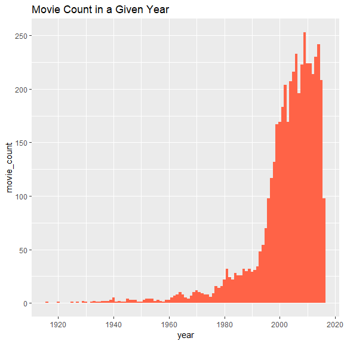

### 1.2.2 Distribution of Aspect Ratio

`Aspect ratio` in images determines the relationship between height and width of the image. It has nothing to do with the actual size of the image. Being numeric in nature, histogram seems to be a suitable choice.

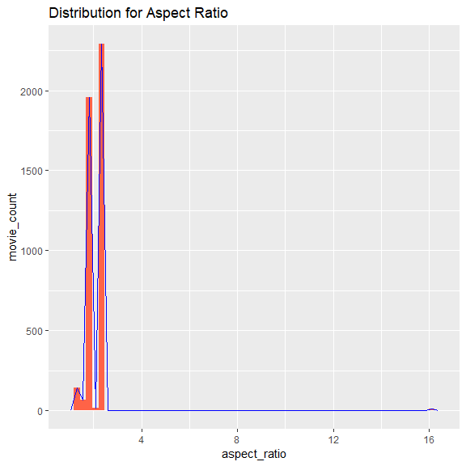

We observe that most of the movies in the dataset have aspect ratio of 2.35. This can be confirmed using `table()` statement.

```
##
## 1.18  1.2 1.33 1.37 1.44  1.5 1.66 1.75 1.77 1.78 1.85 1.89    2  2.2 2.24
##    1    1   42   98    1    2   62    3    1   91 1863    1    4   14    1
## 2.35 2.39  2.4 2.55 2.76   16
## 2273   15    3    2    3   13
```

The most popular values are 2.35 and 1.85. It is slightly left skewed as confirmed by the summary statistics, mean is lower than median.

```
##    Min. 1st Qu.  Median    Mean 3rd Qu.    Max.    NA's
##   1.180   1.850   2.350   2.128   2.350  16.000     300
```

Refer to this link for more details, (https://en.wikipedia.org/wiki/Aspect_ratio_(image)).

### 1.2.3 Distribution of Movie Color

Since `color` is a categorical variable, bar chart is a suitable choice to represent its distribution.

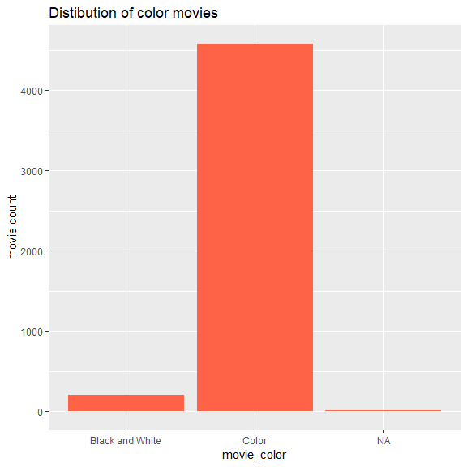

As expected, `color` movies dominate the distribution, with the `Black and White` movies account for a small portion. Few movies are missing information for the `color` variable.

### 1.2.4 Duration of the movie

The `duration` of a movie is integer, therefore, we will depict its distribution using a histogram.

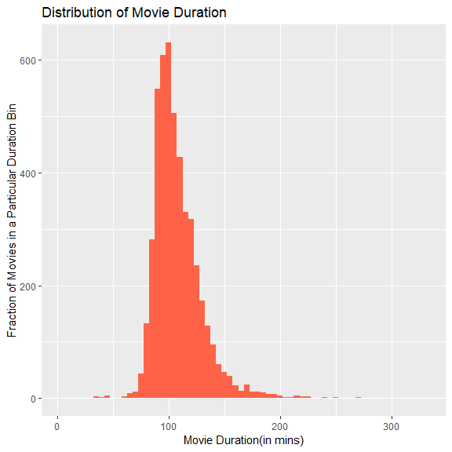

```r
ggplot(movie_select %>% filter(!is.na(duration)),aes(x=duration))+
  geom_histogram(fill="tomato",binwidth = 5)+
  #geom_density(col='black',lty=2)+
  labs(x="Movie Duration(in mins)",y="Fraction of Movies in a Particular Duration Bin",title="Distribution of Movie Duration")
```

```
##    Min. 1st Qu.  Median    Mean 3rd Qu.    Max.    NA's
##     7.0    94.0   104.0   108.1   118.0   330.0      12
```

The mean is slightly higher than median, so we can safely conclude it to be right skewed. It can also be considered relatively normal, since the mean is not too much off the median. As expected there are very few movies of duration greater than 300 minutes. Let us find the longest and the shortest movie.

```r
movie_select%>%
  filter(!is.na(movie_select$duration))%>%
  filter(duration==max(duration)| duration==min(duration))%>%
  select(movie_title,duration)
```

```
##           movie_title duration
## 1 Blood In, Blood Out      330
## 2           The Touch        7
```

So `Blood In,Blood Out` is the longest movie with length of 330 minutes,refer to(https://en.wikipedia.org/wiki/Blood_In_Blood_Out). At the same time, `The Touch` is the shortest movie, as per the dataset.

### 1.2.5 Distribution of Content Rating

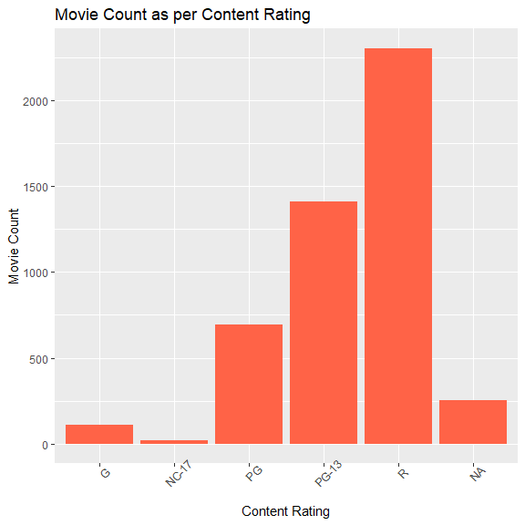

Most of the movies are rated `R`, followed by `PG-13`, and `PG`. Almost 255 movie titles are missing information regarding content rating.

### 1.2.6 Distribution of Language

This is an interesting feature in the dataset. It gives an idea of the popularity of movie languages. Being a factor variable, its distribution will be studied using bar chart.

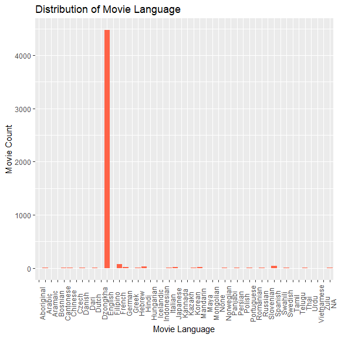

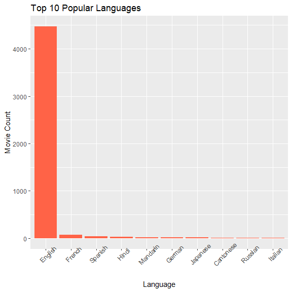

The number of `English` movies heavily outnumber other languages.

### 1.2.7 Distribution of Country

Next, we look at the count of movies in each `country`. Similar to language, it is a categorical variable.

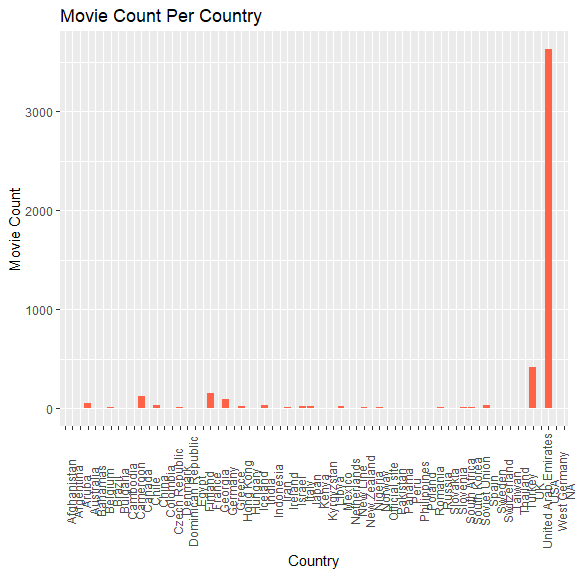

In this dataset, highest number of movies are produced in `U.S.A`, close to 3500. In the bivariate anlaysis, we will look at different characteristics, including `language`,`content_rating`, etc. in relation to countries. Lets look at the top 10 countries with highest number of movies.

```
## # A tibble: 10 x 2
##    country   movie_count
##    <fct>           <int>
##  1 USA              3627
##  2 UK                418
##  3 France            152
##  4 Canada            119
##  5 Germany            94
##  6 Australia          51
##  7 India              34
##  8 Spain              33
##  9 China              28
## 10 Japan              21
```

As a side blurb, we will look at the movie count over the world map. For this, we need to import the world map data.

```r
world_map <- map_data("world")

head(world_map)
```

```
##        long      lat group order region subregion
## 1 -69.89912 12.45200     1     1  Aruba      <NA>
## 2 -69.89571 12.42300     1     2  Aruba      <NA>
## 3 -69.94219 12.43853     1     3  Aruba      <NA>
## 4 -70.00415 12.50049     1     4  Aruba      <NA>
## 5 -70.06612 12.54697     1     5  Aruba      <NA>
## 6 -70.05088 12.59707     1     6  Aruba      <NA>
```

Next, we plot the data on the world map.

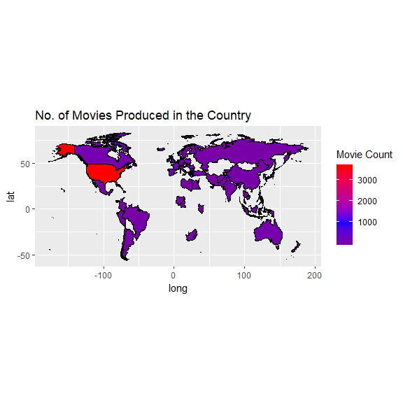

### 1.2.8 Distribution of Budget

It will be interesting to observe the budget distribution. We can observe the count of movies having sufficiently high budget. Before plottng it, we will convert the budget to millions.

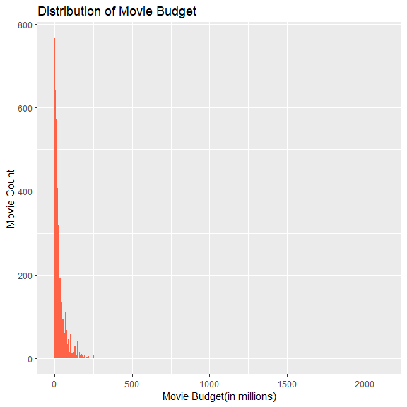

The distribution is right skewed, as expected. Most of the movies have a low budget. Out of curiosity, we will find the movie with highest budget.

```
##   movie_title Budget_millions
## 1    Steamboy         2127.52
```

### 1.2.9 Distribution of Gross Income

Lets observe the distribution of Income generated by the movies. Similar to budget, we will convert the gross income to millions.

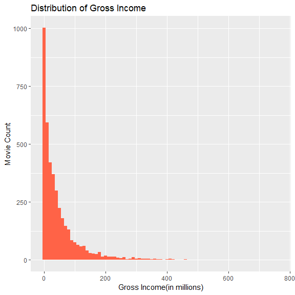

The distribution is right skewed, i.e. very few movies generate high income, say more than 400 millions. Next, we identify the movie generating the highest income.

```
##   movie_title gross_income
## 1      Avatar     760.5058
```

We eliminate original variables, Budget and Gross to avoid redundancy.

### 1.2.10 Distribution of IMDB Score

The IMDB rating is a criteria to classify the popularity of the movie. It is based on the number of votes receieved by a user. Quickly check the summary of this field.

```
##    Min. 1st Qu.  Median    Mean 3rd Qu.    Max.
##   1.600   5.800   6.500   6.413   7.200   9.300
```

Checking the summary, the distribution is expected to be relatively normal, also observed in the histogram.

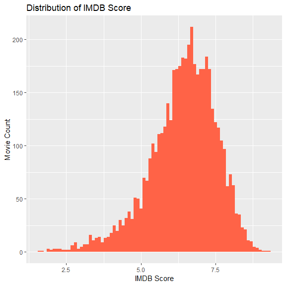

As a side blurb, we want to compare distribution of imdb score for each level of content rating. Since content rating is categorical variable, and imdb score is continuous, we can use `geom_freqpoly()`.

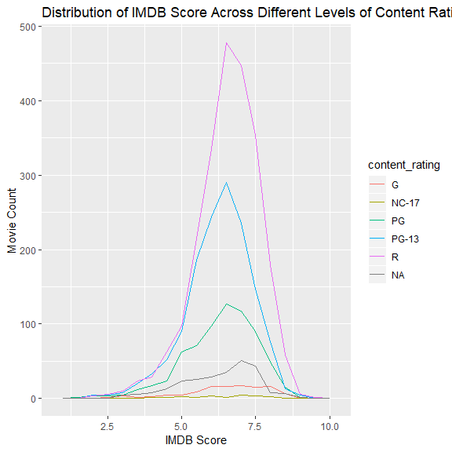

### 1.2.11 Distribution of User votes

Next, we observe the distribution for number of votes a movie has received. Being a numeric variable, histogram is a suitable choice. Lets scale the number of votes, i.e. convert it to thousands.

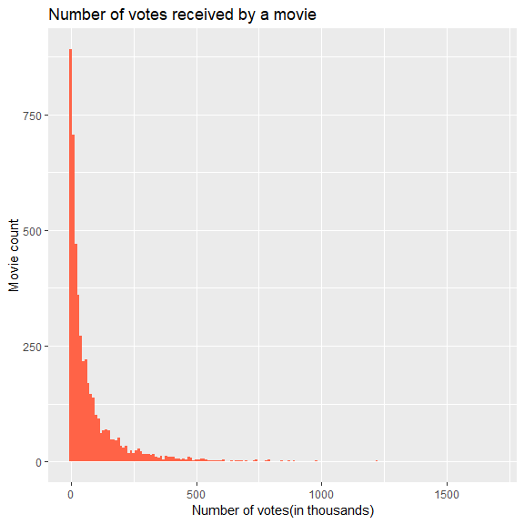

Very few movies have number of votes larger than 1 million, indicating a right skewed distribution. As a side blurb, we identify the movie with the highest number of votes.

```
##                movie_title num_voted_users
## 1 The Shawshank Redemption        1689.764
```

### 1.2.12 Distribution of Movie Facebook Likes

Apart from number of user votes, number of facebook likes can also help to assess the popularity of the movie. Checking its summary, we observe significant right skewness.

```
##    Min. 1st Qu.  Median    Mean 3rd Qu.    Max.
##       0       0     159    7426    2000  349000
```

Being an integer, we choose a histogram to study its distribution.

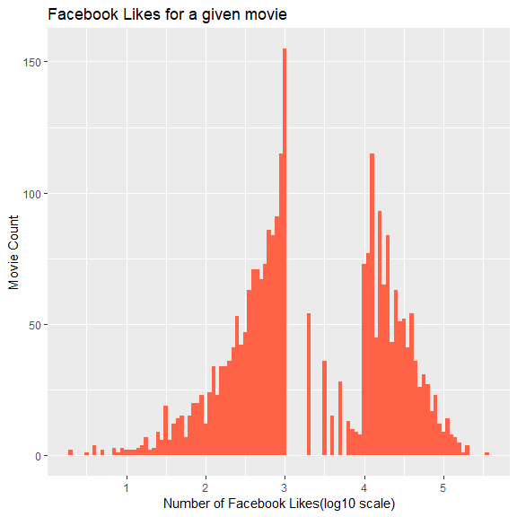

As expected the original distributon is right skewed. Therefore we look at log of the data, and it is easy to see the bimodal behavior. Therefore, we have a good chunk of movies (~155) with number of facebook likes close to 1000, and at the same time we have significant number of movies(~120) with number of facebook likes around 10000. Next, we idenify the movie with highest number of facebook likes.

```
## [1] Interstellar
## 4794 Levels: #Horror [Rec] [Rec] 2 ... Zulu
```

The movie `Interstellar` has got the highest number of facebook likes, close to 349000.

### 1.2.13 Distribution of Movie Director

This distribution can help us to identify how many movies are directed by a given director. Being a categorical variable, we will look at the bar graph.

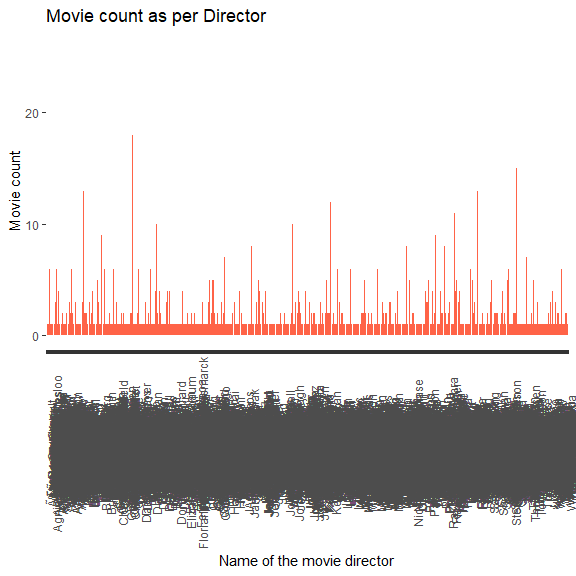

Because of too much data, the figure is not so informative. On a side note, we look at the top 10 directors, who have directed most of the movies.

```
## # A tibble: 10 x 2
##    director_name     count_movie
##    <fct>                   <int>
##  1 Steven Spielberg           26
##  2 Woody Allen                22
##  3 Martin Scorsese            20
##  4 Clint Eastwood             18
##  5 Ridley Scott               16
##  6 Spike Lee                  16
##  7 Renny Harlin               15
##  8 Steven Soderbergh          15
##  9 Oliver Stone               14
## 10 Tim Burton                 14
```

### 1.2.14 Distribution of Facebook likes received by Director

Next, we judge the popularity of the movie’s director. We will look at the histogram for the variable, `director_facebook_likes`.

```
##    Min. 1st Qu.  Median    Mean 3rd Qu.    Max.
##     0.0     7.0    48.0   686.8   189.8 23000.0
```

The distribution is heavily skewed, for sure it is due to few heavily popular directors. We will take logarithm (base 10) to have a reasonable size of this variable.

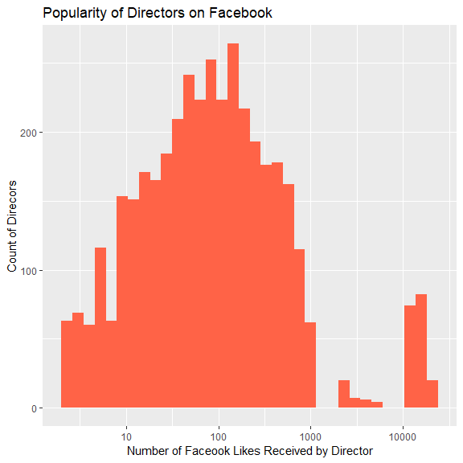

After taking log(base10), as expected the right skewed data looks approximately normal, but still bimodal. Let’s find the 10 most popular director, as per facebook likes.

```
##           director_name director_facebook_likes
## 1  Joseph Gordon-Levitt                   23000
## 2     Christopher Nolan                   22000
## 10        David Fincher                   21000
## 20       Derick Martini                   20000
## 21         Kevin Spacey                   18000
## 22    Denzel Washington                   18000
## 25      Martin Scorsese                   17000
## 45    Quentin Tarantino                   16000
## 47       Clint Eastwood                   16000
## 71            Tom Hanks                   15000
```

The great icon, `Steven Spielberg` does not appear in the top 10 list, since most of his notable movies were old, and facebook started in 2006.

### 1.2.15 Distribution of First Actor

There are 2035 distinct values for first actor in the data, therefore bar graph will be almost not legible. So, it will be more useful to look at 10 actors with highest movie count.

```
## # A tibble: 10 x 2
##    actor_1_name      count
##    <fct>             <int>
##  1 Robert De Niro       48
##  2 Johnny Depp          36
##  3 Nicolas Cage         32
##  4 Denzel Washington    29
##  5 J.K. Simmons         29
##  6 Matt Damon           29
##  7 Bruce Willis         28
##  8 Harrison Ford        27
##  9 Liam Neeson          27
## 10 Robin Williams       27
```

As seen, `Robert De Niro` has starred as the leading actor in highest number of movies, followed by `Johnny Depp` and `Nicholas Cage`. Similarly, we can find leading actors with the lowest movie count.

```
## # A tibble: 10 x 2
##    actor_1_name        count
##    <fct>               <int>
##  1 50 Cent                 1
##  2 A.J. Buckley            1
##  3 Ã“scar Jaenada          1
##  4 "Ã\u0081lex Angulo"     1
##  5 Aaliyah                 1
##  6 Aasif Mandvi            1
##  7 Abigail Evans           1
##  8 Abigail Spencer         1
##  9 Adam Arkin              1
## 10 Adam LeFevre            1
```

### 1.2.16 Distribution of Leading Actor Facebook Likes

To begin with, we will look at the summary.

```
##     Min.  1st Qu.   Median     Mean  3rd Qu.     Max.     NA's
##      0.0    612.5    989.0   6609.4  11000.0 640000.0        7
```

As seen for the variable, `director_facebook_likes`, the distribution is right skewed. Lets check the histogram.

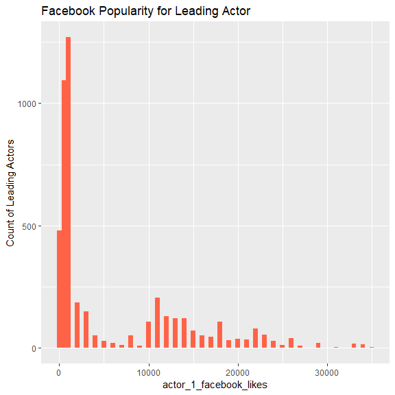

The distribution is bimodal, and is also right skewed. Let us look at the `log` of the continuous variable, `actor_1_facebook_likes`.

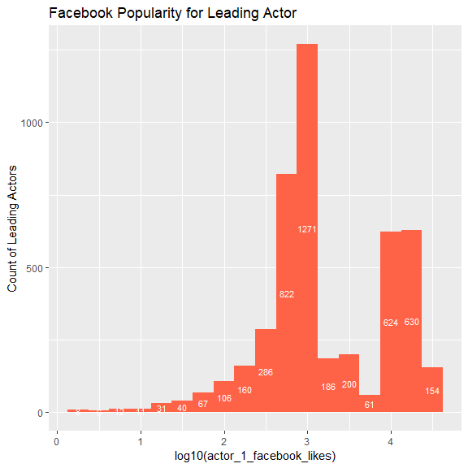

As expected, the distribution of `log()` data is relatively normal, and bimodal. For example, there are 1271 observations in the data where `actor_1_facebook_likes` lies between `3-0.125` and `3+0.125`. It should be noted that this interval corresponds to the interval `10^c(2.875,3.125)`. Next, we will identify the leading actor with highest number of facebook likes.

```
##       actor_1_name actor_1_facebook_likes
## 1    Darcy Donavan                 640000
## 2     Matthew Ziff                 260000
## 5     Krista Allen                 164000
## 7  Andrew Fiscella                 137000
## 9    Jimmy Bennett                  87000
## 17  Michael Joiner                  77000
## 18  Robin Williams                  49000
## 45     Craig Stark                  46000
## 46     Muse Watson                  45000
## 51      Tim Holmes                  44000
```

### 1.2.17 Distribution of Second Actor

Similar to the leading actor, we will identify the 10 second actors with highest movie count.

```
## # A tibble: 10 x 2
##    actor_2_name        count
##    <fct>               <int>
##  1 Morgan Freeman         18
##  2 Charlize Theron        14
##  3 Brad Pitt              13
##  4 Meryl Streep           11
##  5 Adam Sandler           10
##  6 James Franco           10
##  7 Bruce Willis            9
##  8 Scott Glenn             9
##  9 Will Ferrell            9
## 10 Angelina Jolie Pitt     8
```

`Morgan Freeman` is the second actor with highest movie count, followed by `Charlize Theron` and `Brad Pitt`.

### 1.2.18 Distribution of Facebook Likes for Second Actor

First, we will look at the summary of the variable, `actor_2_facebook_likes`.

```
##    Min. 1st Qu.  Median    Mean 3rd Qu.    Max.    NA's
##       0     279     595    1650     919  137000      10
```

Checking the mean and median, we conclude that it is right skewed. Lets check with the histogram.

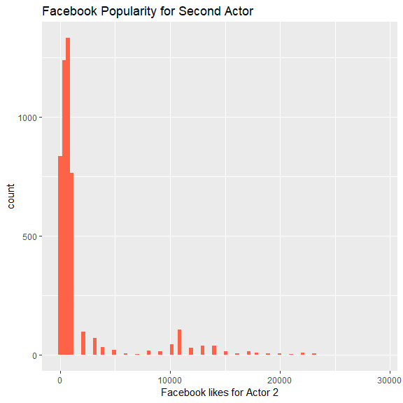

Similar to popularity of leading actor, this distribution is bimodal as well as right skewed.

### 1.2.19 Distribution of Actor 3 Name

Similar to leading actor, we will identify the most popular `third actors`.

```
## # A tibble: 10 x 2
##    actor_3_name        count
##    <fct>               <int>
##  1 Steve Coogan            8
##  2 Jon Gries               7
##  3 Robert Duvall           7
##  4 Sam Shepard             7
##  5 Stephen Root            7
##  6 Anne Hathaway           6
##  7 Ben Mendelsohn          6
##  8 Bruce McGill            6
##  9 Clifton Collins Jr.     6
## 10 Hope Davis              6
```

### 1.2.20 Distribution of Actor_3_facebook_likes

We observe the summary of the variable, `actor_3_facebook_likes`.

```
##    Min. 1st Qu.  Median    Mean 3rd Qu.    Max.    NA's
##     0.0   132.0   367.5   638.6   636.0 23000.0      18
```

Since mean exceeds the median, it is right skewed distribution, as seen in the following figure.

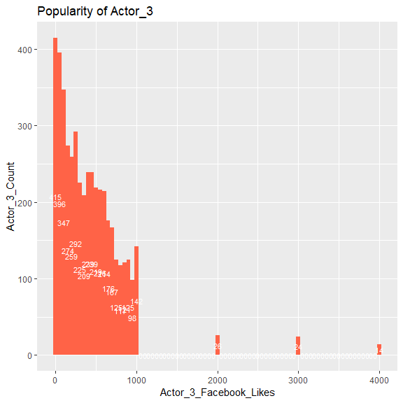

### 1.2.21 Recap

Univariate analysis was conducted in this section to get some overview of the variables. The numeric variables, `budget` and `income` as expected are right skewed. Since very few movies are costly or generate huge revenue, right skewness is expected. At the same time, recently there has been a surge in number of movies; the distribution of `year` is left skewed. On the other hand, the number of facebook likes for director and actors is right skewed, which indicates very few popular actors on facebook.

## 1.3 Bivariate Analysis

Earlier, we performed univariate analysis of the data. Now we plan to observe two variables at a time, i.e. Bivariate Analysis.

### 1.3.1 Income Generated Across Different Countries

In this section, we analyze the distribution of income generated across diferent countries. Since `country` is a categorical variable, `gross_income` is numeric, therefore boxplot is a suitable choice. In the univariate section, we saw that top 10 countries with highest number of movies are `USA`,`UK`,`France`,`Canada`,`Germany`,`Australia`,`India`,`Spain`,`China`, and `Japan`.First, we will filter the data for these countries. Next, we observe the boxplot.

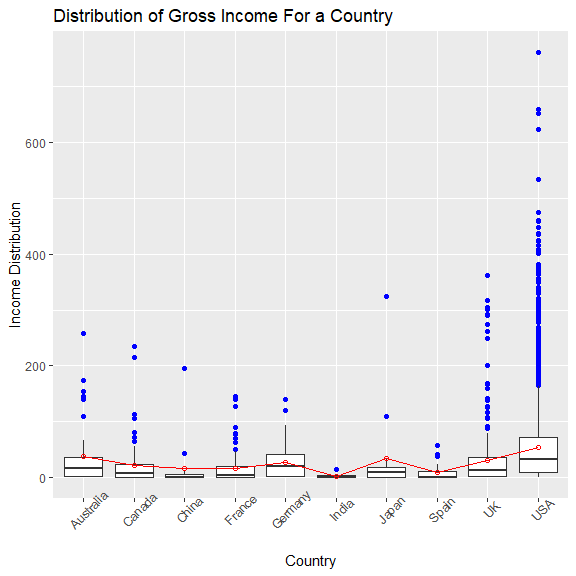

We notice that for every `country`, there are outliers in distribution of `income`. Since most of the movies are made in `USA`, it has highest number of outliers. Next, since mean exceeds the median for most of the countries, the income distribution is right skewed. Looking at the boxplot, we see significant outliers for countries, `China` and `Japan`. We should identify the movies for which the gross income is much greater than normal trend. To this end, we will first filter the dataset, for `Japan` and `China`, followed by selecting top 2 movies in terms of gross income generated.

```
## # A tibble: 4 x 3
## # Groups:   country [2]
##   movie_title                        gross_income country
##   <fct>                                     <dbl> <fct>
## 1 Mission: Impossible - Rogue Nation        195.  China
## 2 The Last Emperor                           44.0 China
## 3 The Secret Life of Pets                   324.  Japan
## 4 Trainwreck                                110.  Japan
```

In `China` the two highest revenue generating movies are Mission:Impossible-Rogue Nation and The Last Emperor. Similarly for `Japan`, top 2 movies are The Secret Life of Pets and Trainwreck.

### 1.3.2 Budget Distribution Across Countries

Now we analyze the distribution of movie budget for each country. Since `country` is a categorical variable, and `Budget_millions` is numeric, we will use the boxplot.

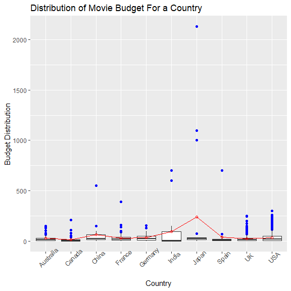

From the boxplot, it can be observed that for countries like `China`,`India`, `Japan`, and `Spain` the outliers are very significant. Let us find the highest budget movie for these countries.

```
## # A tibble: 4 x 3
## # Groups:   country [4]
##   movie_title            Budget_millions country
##   <fct>                            <dbl> <fct>
## 1 Red Cliff                         554. China
## 2 Kabhi Alvida Naa Kehna            700  India
## 3 Steamboy                         2128. Japan
## 4 Tango                             700  Spain
```

Since I am from India, I would like to dig a bit deeper into the stats for the movie `Kabhi Alvida Naa Kehna`.

The leading actor in this movie is `Shahrukh Khan`, a Bollywood icon. As a side blurb, it will be interesting to see popular Bollywood actors(in lead role), using number of facebook likes as the criteria. It should be noted that this is based on *this* particular dataset. It might not reflect the actual figures.

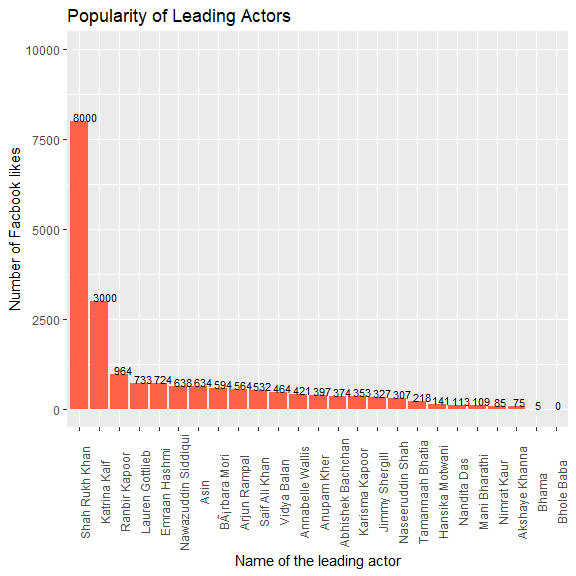

We observe that `Shahrukh` and `Katrina` lead the chart way ahead of other leading actors. Next, it will be interesting to see language distribution across top 10 countries.

### 1.3.3 Language Distribution Across Countries

We need to know the popularity of language in a given country. The focus will be on the top 10 countries, with highest number of movies. We plan to do the grouping on two variables; `country` and `language`.

Next, we get a bar chart to get the number of movies in a particular language, faceted by country.

```
##    Min. 1st Qu.  Median    Mean 3rd Qu.    Max.
##    1.00    1.00    1.00   91.54   12.00 3600.00
```

The count variable is heavily skewed with 75 percent of values being less than 12 but maximum value is 3600. We found that in `US` the number of movies made in English is 3600. If we ignore that record, and look at the new plot.

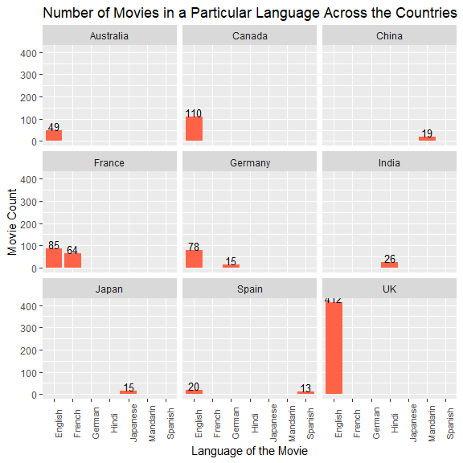

### 1.3.4 Budget Analysis Across Time

Next, we will compare the budget for recent movies and that of older movies. To this end, we define a new variable, `movie_recent`. We will classify the movies as

- **New** : Released after 2000
- **Medieval** : Before 2000 but later than 1970
- **Old** : Before 1970.

The next step is to compare the mean budget as time progresses.

```
## # A tibble: 3 x 2
##   movie_recent mean_budget
##   <chr>              <dbl>
## 1 Medieval           28.2
## 2 New                38.2
## 3 Old                 4.04
```

Since distribution for `Budget_millions` is right skewed, it will be better to compare the median.

```
## # A tibble: 3 x 2
##   movie_recent median_budget
##   <chr>                <dbl>
## 1 Medieval             17
## 2 New                  20
## 3 Old                   2.54
```

We see that the budget has increased significantly as time progresses. For example, almost 50 percent of the movies released after the year 2000 had a budget more than 20 millions. This is a significant increase as compared to 2 millions for older movies. As a side blurb, we identify the highest budget movie in all three categories. This can be achieved using the `top_n()` function from `dplyr()`.

```
## # A tibble: 3 x 4
## # Groups:   movie_recent [3]
##   movie_title Budget_millions movie_recent title_year
##   <fct>                 <dbl> <chr>             <int>
## 1 Cleopatra              31.1 Old                1963
## 2 Steamboy             2128.  New                2004
## 3 Akira                1100   Medieval           1988
```

Let’s try to look at this change in budget using a different perspective. Since budget is changing with time, line graph will be a suitable option.

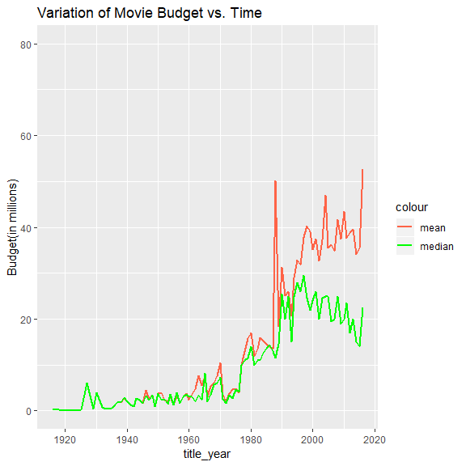

We see that the behavior of mean as well as median of the budget is very noisy. But overall it is increasing with time. Before the year 2000, the mean budget is the highest at 50 millions. It will be worthwhile identifying that `year` and looking at the movies produced in that year.

```
## # A tibble: 6 x 2
##   title_year mean_budget
##        <int>       <dbl>
## 1       2016        52.6
## 2       1988        50.2
## 3       2004        46.9
## 4       2010        43.4
## 5       2008        41.6
## 6       1998        40.3
```

So its the year 1988, when the mean budget is the highest in pre-2000 period. We filter for movies produced in that year.

```
## [1] 30  3
```

Therefore, we have 30 movies as per this dataset, that were released in year 1988. To identify the most costly movie, we can just look at the top 5 of them.

```
##    movie_title Budget_millions title_year
## 1        Akira            1100       1988
## 2    Rambo III              63       1988
## 3     Scrooged              32       1988
## 4 Midnight Run              30       1988
## 5     Die Hard              28       1988
## 6     Rain Man              25       1988
```

Great! the movie `Akira` released in 1988, had an estimated budget of 1100 millions, which is enough to pull the mean to 50 millions, despite the fact that rest all movies did cost less than 100 millions. Similar analysis can be done to identify the highest income generating movies.

### 1.3.5 Gross Income Analysis Across Time

Similar to `Budget`, we analyze the variation of `Gross Income` with time. We compute the statistical summaries, `mean` and `median` of the gross income as time progresses.

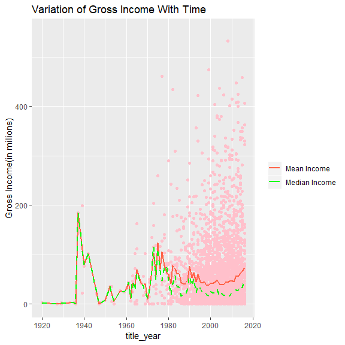

It is easy to notice that mean income generated was almost same as median in earlier years. This can be attributed to small number of movies produced earlier as compared to number of movies produced nowadays. After the year 1965, the mean value exceeds the median income, hence we expect right skewness in the distribution of `gross_income`. Moreover the mean income generated nowadays is much lower than earlier. This can hapen due to large number of movies produced nowadays and most of them don’t do so good at the box office. Out of curiosity let’s check how much income has been generated by the movie `Akira` the highest budget movie in year 1988.

```
## [1] 0.439162
```

Despite being the costliest movie in the year 1988, `Akira` could earn only 0.45 millions in gross. During the period 1935-1940, the mean `gross_income` is quite high, close to 200 millions. To find that movie, we will compute the mean income for a given year using `group_by`.

```
## # A tibble: 6 x 2
##   title_year mean_income
##        <int>       <dbl>
## 1       1937        185.
## 2       1975        124.
## 3       1939        110.
## 4       1977        106.
## 5       1973        103.
## 6       1942        103.
```

Next, we check the movies produced in the year 1937.

```
##                       movie_title gross_income title_year
## 1 Snow White and the Seven Dwarfs     184.9255       1937
## 2           The Prisoner of Zenda           NA       1937
```

Therefore, `Snow White and the Seven Dwarfs` is the highest earning movie in 1937. It earned a gross income of 184.92 millions.

### 1.3.6 Variation of Movie Count for Content Rating w.r.t Time

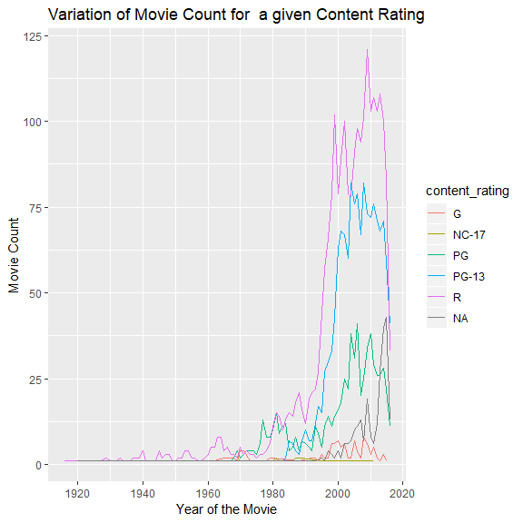

The movie count for every content rating is behaving noisily with respect to time. In the post 1980 period, number of movies increases for every content rating. Number of movies is highest for the content rating, `R` followed by `PG-13` and `PG`. As time approaches 2020, the number of movies is decreasing for each content rating. Interestingly, the number of movies rated `NC-17` is the lowest throughout the entire period.

### 1.3.7 Variation in Movie Duration With Respect To Time

Another attribute, which could change with time is the length of the movie. Since it varies with time, we will use line plot.

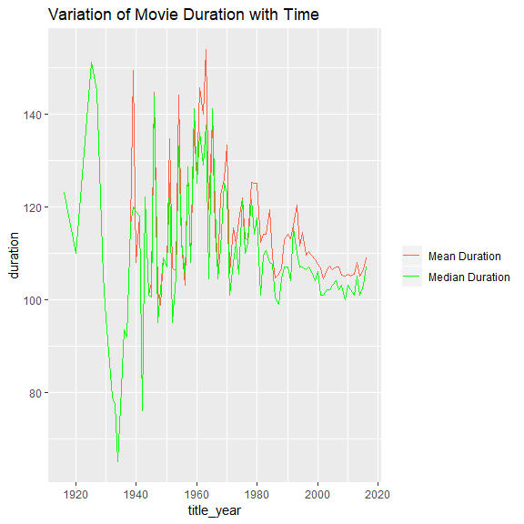

It is interesting to see that overall, newer movies are shorter than older movies. In the range 1960-1980, the mean duration is at the peak, close to 160 mins. Let’s try to identify which movie is causing the average to be so high.

```
## # A tibble: 10 x 2
##    title_year mean_duration
##         <int>         <dbl>
##  1       1963          154.
##  2       1925          151
##  3       1939          149.
##  4       1961          146.
##  5       1927          145
##  6       1946          145.
##  7       1954          144
##  8       1962          140.
##  9       1965          139.
## 10       1959          137.
```

Next, we filter for the movies released in the year 1963 and identify the longest movie in that year.

```
##                       movie_title title_year duration
## 1                       Cleopatra       1963      251
## 2 It's a Mad, Mad, Mad, Mad World       1963      197
## 3                The Great Escape       1963      172
## 4               55 Days at Peking       1963      154
## 5                       Tom Jones       1963      121
## 6           From Russia with Love       1963      115
## 7                             Hud       1963      112
## 8                  Donovan's Reef       1963      109
```

Therefore, `Cleopatra` is main contributor to the high average of movie duration in the year 1963.

### 1.3.8 Aspect Ratio vs. Time

Is `aspect ratio` a function of time? The relationship between height and width of the image might be changing with time.

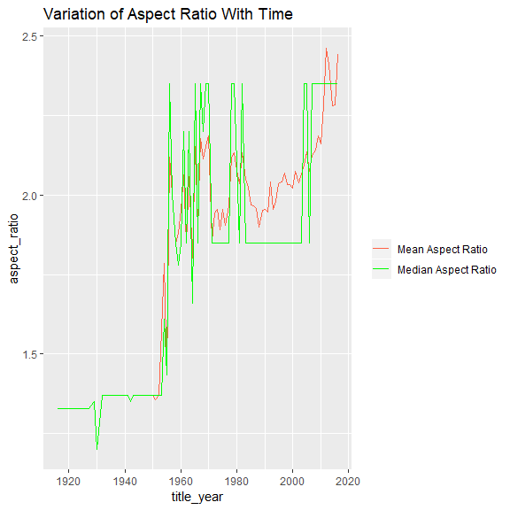

The mean `aspect_ratio` has an upward trend, as time progresses. The behavior is quite noisy.